# Chapter 3 Decomposition

# Time series components

## Time series patterns

**Recall**

**Trend**

pattern exists when there is a long-term increase or decrease in the data.

**Cyclic**

pattern exists when data exhibit rises and falls that are *not of fixed period* (duration usually of at least 2 years).

**Seasonal**

pattern exists when a series is influenced by seasonal factors (e.g., the quarter of the year, the month, or day of the week).

## Time series decomposition

$y_t = f(S_t, T_t, R_t)$

where $y_t=$, data at period $t$

$T_t=$, trend-cycle component at period $t$

$S_t=$, seasonal component at period $t$

$R_t=$,remainder component at period $t$

**Additive decomposition:** $y_t = S_t + T_t + R_t.$

**Multiplicative decomposition:** $y_t = S_t \times T_t \times R_t.$

## Time series decomposition

- Additive model appropriate if magnitude of seasonal fluctuations does not vary with level.
- If seasonal are proportional to level of series, then multiplicative model appropriate.
- Multiplicative decomposition more prevalent with economic series
- Alternative: use a Box-Cox transformation, and then use additive decomposition.
- Logs turn multiplicative relationship into an additive relationship:

$$y_t = S_t \times T_t \times R_t \quad\Rightarrow\quad
\log y_t = \log S_t + \log T_t + \log R_t.$$

## US Retail Employment

```r
us_retail_employment <- us_employment |>
  filter(year(Month) >= 1990, Title == "Retail Trade") |>
  select(-Series_ID)
us_retail_employment
```

```
# A tsibble: 357 x 3 [1M]
      Month Title        Employed
      <mth> <chr>           <dbl>
 1 1990 Jan Retail Trade   13256.
 2 1990 Feb Retail Trade   12966.
 3 1990 Mar Retail Trade   12938.
 4 1990 Apr Retail Trade   13012.
 5 1990 May Retail Trade   13108.
 6 1990 Jun Retail Trade   13183.
 7 1990 Jul Retail Trade   13170.
 8 1990 Aug Retail Trade   13160.
 9 1990 Sep Retail Trade   13113.
10 1990 Oct Retail Trade   13185.
# ℹ 347 more rows
```

## US Retail Employment

```r
us_retail_employment |>
  autoplot(Employed) +
  labs(y="Persons (thousands)", title="Total employment in US retail")
```

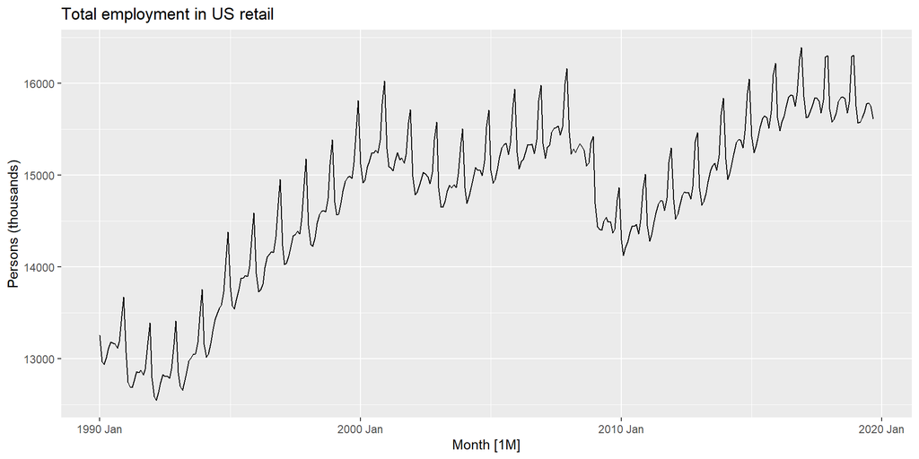

## US Retail Employment

```r
us_retail_employment |>
  model(stl = STL(Employed))
```

```
# A mable: 1 x 1
      stl
  <model>
1   <STL>
```

## US Retail Employment

```r
dcmp <- us_retail_employment |>
  model(stl = STL(Employed))
components(dcmp)
```

```
# A dable: 357 x 7 [1M]
# Key:     .model [1]
# :        Employed = trend + season_year + remainder
   .model    Month Employed  trend season_year remainder season_adjust
   <chr>     <mth>    <dbl>  <dbl>       <dbl>     <dbl>         <dbl>
 1 stl    1990 Jan   13256. 13288.      -33.0      0.836        13289.
 2 stl    1990 Feb   12966. 13269.     -258.     -44.6          13224.
 3 stl    1990 Mar   12938. 13250.     -290.     -22.1          13228.
 4 stl    1990 Apr   13012. 13231.     -220.       1.05         13232.
 5 stl    1990 May   13108. 13211.     -114.      11.3          13223.
 6 stl    1990 Jun   13183. 13192.      -24.3     15.5          13207.
 7 stl    1990 Jul   13170. 13172.      -23.2     21.6          13193.
 8 stl    1990 Aug   13160. 13151.       -9.52    17.8          13169.
 9 stl    1990 Sep   13113. 13131.      -39.5     22.0          13153.
10 stl    1990 Oct   13185. 13110.       61.6     13.2          13124.
# ℹ 347 more rows
```

## US Retail Employment

```r
us_retail_employment |>
  autoplot(Employed, color='gray') +
  autolayer(components(dcmp), trend, color='#523178') +
  labs(y="Persons (thousands)", title="Total employment in US retail")
```

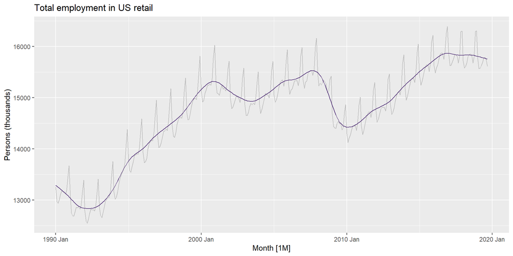

## US Retail Employment

```r
components(dcmp) |> autoplot()
```

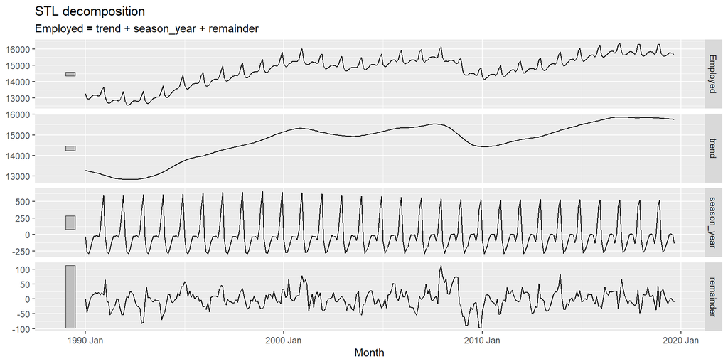

## US Retail Employment

```r
components(dcmp) |> gg_subseries(season_year)
```

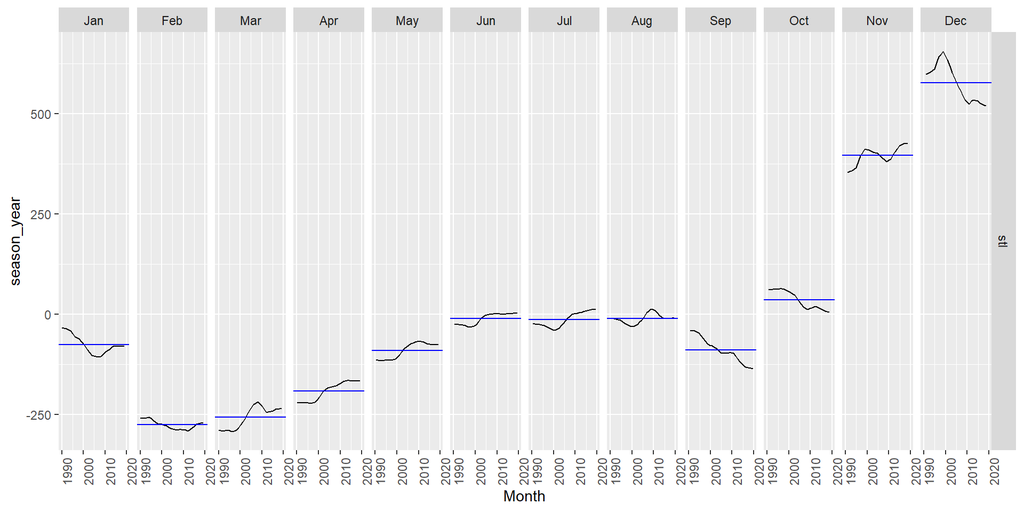

## Seasonal adjustment

- Useful by-product of decomposition: an easy way to calculate seasonally adjusted data.
- Additive decomposition: seasonally adjusted data given by
  $$y_t - S_t = T_t + R_t$$
- Multiplicative decomposition: seasonally adjusted data given by
  $$y_t / S_t = T_t \times R_t$$

## US Retail Employment

```r
us_retail_employment |>
  autoplot(Employed, color='gray') +
  autolayer(components(dcmp), season_adjust, color='#0072B2') +
  labs(y="Persons (thousands)", title="Total employment in US retail")
```

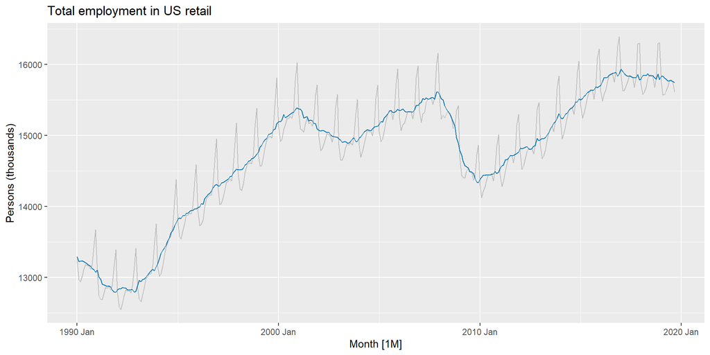

## Seasonal adjustment

- We use estimates of $S$ based on past values to seasonally adjust a current value.
- Seasonally adjusted series reflect **remainders** as well as **trend**. Therefore they are not “smooth” and “downturns” or “upturns” can be misleading.
- It is better to use the trend-cycle component to look for turning points.

# Moving Averages (MA)

## Moving Averages

- The classical method of time series decomposition originated in the 1920s and was widely used until the 1950s.
- A moving average of order $m$ can be written as
  $$\hat{T}_t = \frac{1}{m}\Sigma_{j=-k}^k y_{t+j}$$
  where $m = 2k+1$.
- That is, the estimate of the trend-cycle at time $t$ is obtained by averaging values of the time series within $k$ periods of $t$.

## MA

- Averaging eliminates some of the randomness in the data, leaving a smooth trend-cycle component.
- Called an m-MA, or MA(m), meaning a moving average of order m.

## MA global economy

```r
global_economy |>
  filter(Country == "Australia") |>
  autoplot(Exports) +
  labs(y = "% of GDP", title = "Total Australian exports")
```

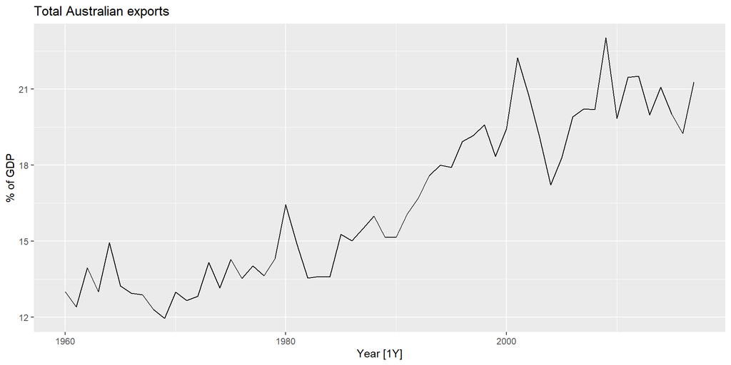

## MA global economy

- A moving average is a an average that moves…
- MA(5) would mean we use the average of two time series values before $y_t$, $y_t$ itself, and the two values after $y_t$.
- Ex: to get the MA(5) for $y_{100}$ we would use the average of $y_{98},y_{99},y_{100},y_{101}$ and $y_{102}$.
- What is a limitation of this method?

## MA global economy sliding window

- slide_dbl() from the slider package applies a function to “sliding” time windows. In this case, we use the mean() function with a window of size 5.

```r
aus_exports <- global_economy |>
  filter(Country == "Australia") |>
  mutate(
    `5-MA` = slider::slide_dbl(Exports, mean,
                .before = 2, .after = 2, .complete = TRUE)
  )
```

## MA trend line

- Code
- Plot

```r
aus_exports |>
  autoplot(Exports) +
  geom_line(aes(y = `5-MA`), colour = "#D55E00") +
  labs(y = "% of GDP",
       title = "Total Australian exports")
```

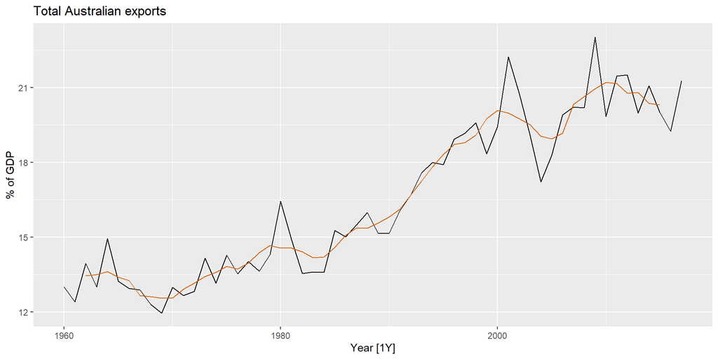

# History of time series decomposition

## History of time series decomposition

- Classical method originated in 1920s.
- Census II method introduced in 1957. Basis for X-11 method and variants (including X-12-ARIMA, X-13-ARIMA)
- STL method introduced in 1983
- TRAMO/SEATS introduced in 1990s.

## National Statistics Offices

- ABS uses X-12-ARIMA
- US Census Bureau uses X-13ARIMA-SEATS
- Statistics Canada uses X-12-ARIMA
- ONS (UK) uses X-12-ARIMA
- EuroStat use X-13ARIMA-SEATS

## X-11 decomposition

**Advantages**

- Relatively robust to outliers
- Completely automated choices for trend and seasonal changes
- Very widely tested on economic data over a long period of time.

**Disadvantages**

- No prediction/confidence intervals
- Ad hoc method with no underlying model
- Only developed for quarterly and monthly data

## Extensions: X-12-ARIMA and X-13-ARIMA

- The X-11, X-12-ARIMA and X-13-ARIMA methods are based on Census II decomposition.
- These allow adjustments for trading days and other explanatory variables.
- Known outliers can be omitted.
- Level shifts and ramp effects can be modelled.
- Missing values estimated and replaced.
- Holiday factors (e.g., Easter, Labour Day) can be estimated.

## X-13ARIMA-SEATS

**Advantages**

- Model-based
- Smooth trend estimate
- Allows estimates at end points
- Allows changing seasonality
- Developed for economic data

**Disadvantages**

- Only developed for quarterly and monthly data

# STL decomposition

## LOESS?

https://www.youtube.com/watch?v=Vf7oJ6z2LCc

## STL decomposition

- STL: “Seasonal and Trend decomposition using Loess”
- Very versatile and robust.
- Unlike X-12-ARIMA, STL will handle any type of seasonality.
- Seasonal component allowed to change over time, and rate of change controlled by user.
- Smoothness of trend-cycle also controlled by user.
- Robust to outliers
- Not trading day or calendar adjustments.
- Only additive.
- Take logs to get multiplicative decomposition.
- Use Box-Cox transformations to get other decompositions.

## STL decomposition

```r
us_retail_employment |>
  model(STL(Employed ~ season(window=9), robust=TRUE)) |>
  components() |> autoplot() +
    labs(title = "STL decomposition: US retail employment")
```

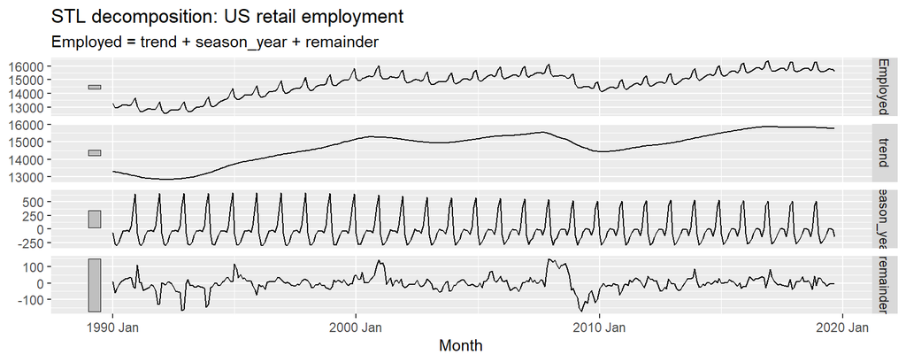

## STL decomposition

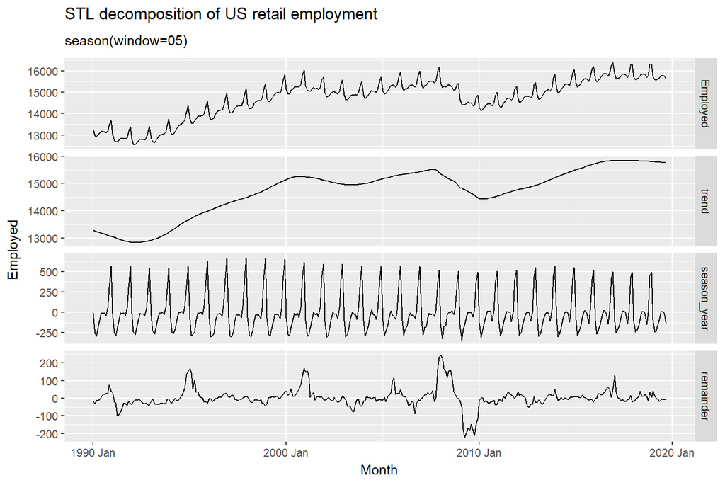

## STL decomposition

```r
us_retail_employment |>
  model(STL(Employed ~ season(window=5))) |>
  components()

us_retail_employment |>
  model(STL(Employed ~ trend(window=15) +
                       season(window="periodic"),
            robust = TRUE)
  ) |> components()
```

- `trend(window = ?)` controls wiggliness of trend component.
- `season(window = ?)` controls variation on seasonal component.
- `season(window = 'periodic')` is equivalent to an infinite window.

## STL decomposition

```r
us_retail_employment |>
  model(STL(Employed)) |>
  components() |> autoplot()
```

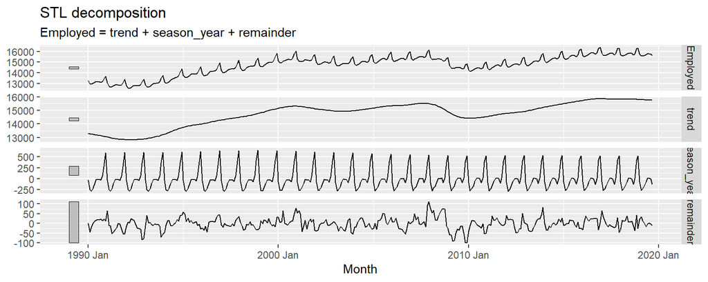

**Note**

## STL decomposition

- Algorithm that updates trend and seasonal components iteratively.
- Starts with $\hat{T}_t=0$
- Uses a mixture of loess and moving averages to successively refine the trend and seasonal estimates.
- The trend window controls loess bandwidth applied to deasonalised values.
- The season window controls loess bandwidth applied to detrended subseries.
- Robustness weights based on remainder.
- Default season `window = 13`
- Default trend `window = nextodd(` `ceiling((1.5*period)/(1-(1.5/s.window)))`